# Team-19

19BCE1753-Daksh

12/11/2021

# Loading the dataset

```r
data = read_csv("zomato.csv")
data1 = read_csv("zomato_pre-processed.csv")
data2 = read_csv("zomato2.csv")
glimpse(data)
```

```
## Rows: 51,717
## Columns: 17
## $ url                           <chr> "https://www.zomato.com/bangalore/jalsa-~
## $ address                       <chr> "942, 21st Main Road, 2nd Stage, Banasha~
## $ name                          <chr> "Jalsa", "Spice Elephant", "San Churro C~
## $ online_order                  <chr> "Yes", "Yes", "Yes", "No", "No", "Yes", ~
## $ book_table                    <chr> "Yes", "No", "No", "No", "No", "No", "No~
## $ rate                          <chr> "4.1/5", "4.1/5", "3.8/5", "3.7/5", "3.8~
## $ votes                         <dbl> 775, 787, 918, 88, 166, 286, 8, 2556, 32~
## $ phone                         <chr> "080 42297555\r\n+91 9743772233", "080 4~
## $ location                      <chr> "Banashankari", "Banashankari", "Banasha~
## $ rest_type                     <chr> "Casual Dining", "Casual Dining", "Cafe,~
## $ dish_liked                    <chr> "Pasta, Lunch Buffet, Masala Papad, Pane~
## $ cuisines                      <chr> "North Indian, Mughlai, Chinese", "Chine~
## $ `approx_cost(for two people)` <dbl> 800, 800, 800, 300, 600, 600, 800, 600, ~
## $ reviews_list                  <chr> "[('Rated 4.0', 'RATED\\n  A beautiful p~
## $ menu_item                     <chr> "[]", "[]", "[]", "[]", "[]", "[]", "[]"~
## $ `listed_in(type)`             <chr> "Buffet", "Buffet", "Buffet", "Buffet", ~
## $ `listed_in(city)`             <chr> "Banashankari", "Banashankari", "Banasha~
```

```r
str(data$rate)
```

```
##  chr [1:51717] "4.1/5" "4.1/5" "3.8/5" "3.7/5" "3.8/5" "3.8/5" "3.6/5" ...
```

```r
data$rate <- as.factor(data$rate)
```

# Data Cleaning

## Removing unnecessary data such as url, address and phone columns from DataFrame

```r
colnames(data)
```

```
##  [1] "url"                         "address"
##  [3] "name"                        "online_order"
##  [5] "book_table"                  "rate"
##  [7] "votes"                       "phone"
##  [9] "location"                    "rest_type"
## [11] "dish_liked"                  "cuisines"
## [13] "approx_cost(for two people)" "reviews_list"
## [15] "menu_item"                   "listed_in(type)"
## [17] "listed_in(city)"
```

```r
data <- data[,-c(1,2,8)]
missing_value <- sapply(data,function(x) sum(is.na(x)))
missing_value
```

```
##                        name                online_order
##                           0                           0
##                  book_table                        rate
##                           0                        7775
##                       votes                    location
##                           0                          21
##                   rest_type                  dish_liked
##                         227                       28078
##                    cuisines approx_cost(for two people)
##                          45                         346
##                reviews_list                   menu_item
##                           0                           0
##             listed_in(type)             listed_in(city)
##                           0                           0
```

# Visualisations

## 1. Average Rating By Location in Banglore

```r
ST1 <- data1 %>%
  group_by(location) %>%
  summarise(
    avg.rating = mean(rate)
  ) %>%
  arrange(desc(avg.rating)) %>%
  head(10)
ST1
```

```
## # A tibble: 10 x 2
##    location              avg.rating
##    <chr>                      <dbl>
##  1 Lavelle Road                4.17
##  2 St. Marks Road              4.07
##  3 Koramangala 3rd Block       4.07
##  4 Koramangala 5th Block       4.05
##  5 Church Street               4.02
##  6 Sankey Road                 3.98
##  7 Cunningham Road             3.95
##  8 Koramangala 4th Block       3.94
##  9 Residency Road              3.92
## 10 Koramangala 7th Block       3.91
```

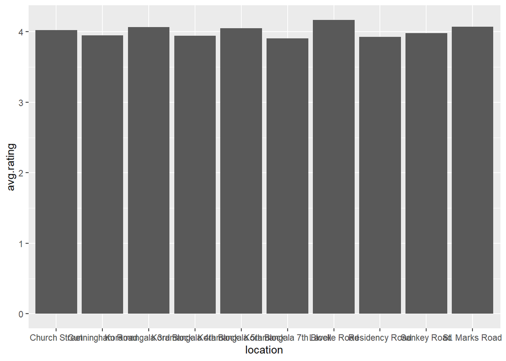

```r
ST1 %>%
  ggplot(aes(x=location,y=avg.rating))+
  geom_bar(stat = "identity")
```

## 2. Country-Wise Average Rise

```r
ST2 <- data2 %>%
  group_by(Country) %>%
  summarise(
    avg.rating = mean(`Aggregate rating`)
  ) %>%
  arrange(desc(avg.rating))
ST2
```

```
## # A tibble: 15 x 2
##    Country        avg.rating
##    <chr>               <dbl>
##  1 Phillipines          4.47
##  2 Turkey               4.3
##  3 Indonesia            4.30
##  4 New Zealand          4.26
##  5 UAE                  4.23
##  6 South Africa         4.21
##  7 United Kingdom       4.09
##  8 Qatar                4.06
##  9 United States        4.00
## 10 Sri Lanka            3.87
## 11 Brazil               3.76
## 12 Australia            3.66
## 13 Canada               3.58
## 14 Singapore            3.58
## 15 India                2.52
```

```r
table(data2$Country)
```

```
##
##      Australia         Brazil         Canada          India      Indonesia
##             24             60              4           8652             21
##    New Zealand    Phillipines          Qatar      Singapore   South Africa
##             40             22             20             20             60
##      Sri Lanka         Turkey            UAE United Kingdom  United States
##             20             34             60             80            434
```

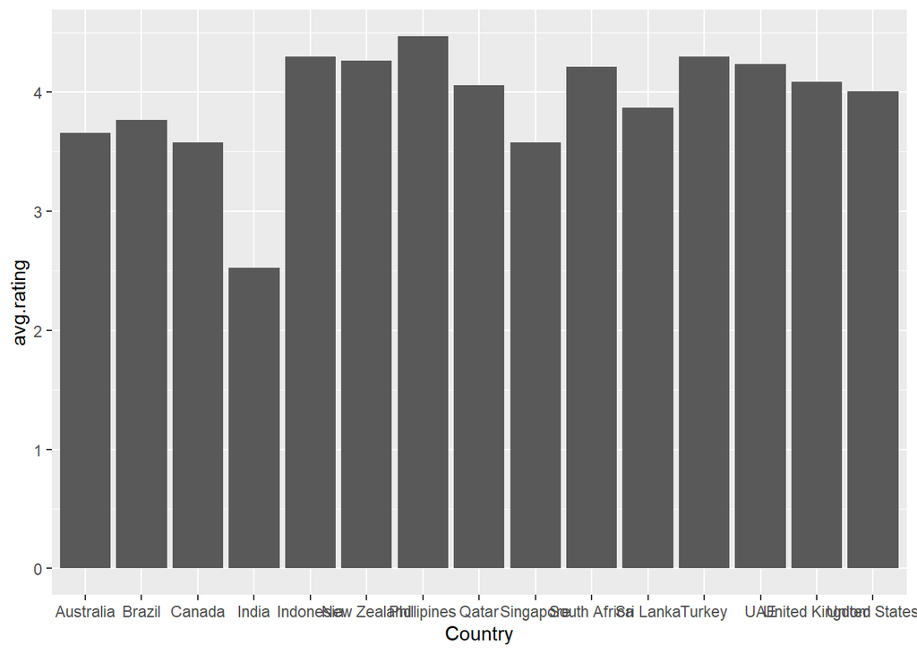

```r
ST2 %>%
  ggplot(aes(x=Country,y=avg.rating))+
  geom_bar(stat = "identity")
```

### Inference: From the table it is visible the India is at the bottom with an average restaurant rating of 2.5 only and Phillipines is at the top with an average rating of 4.46. But in reality, Phillipines has just 22 restaurants while India has 8652 restaurants.

## 3. Country-Wise Average Cost

```r
data2 %>%
  group_by(Country, Currency) %>%
  summarise(
    Average.Cost.for.Two = mean(`Average Cost for two`)
  )
```

```
## # A tibble: 15 x 3
## # Groups:   Country [15]
##    Country        Currency                 Average.Cost.for.Two
##    <chr>          <chr>                                   <dbl>
##  1 Australia      "Dollar($)"                              24.1
##  2 Brazil         "Brazilian Real(R$)"                    135.
##  3 Canada         "Dollar($)"                              36.2
##  4 India          "Indian Rupees(Rs.)"                    623.
##  5 Indonesia      "Indonesian Rupiah(IDR)"             281190.
##  6 New Zealand    "NewZealand($)"                          69.8
##  7 Phillipines    "Botswana Pula(P)"                     1607.
##  8 Qatar          "Qatari Rial(QR)"                       224.
##  9 Singapore      "Dollar($)"                             156.
## 10 South Africa   "Rand(R)"                               420.
## 11 Sri Lanka      "Sri Lankan Rupee(LKR)"                2375
## 12 Turkey         "Turkish Lira(TL)"                       84.9
## 13 UAE            "Emirati Diram(AED)"                    166.
## 14 United Kingdom "Pounds(\x8c\xa3)"                       47.8
## 15 United States  "Dollar($)"                              26.2
```

### Inference: This data clearly shows how some countries are very much devalued or in-expensive compared to other countries. For example Avergae cost in USA is 26$ while in India it is 623Rs. or just 8$.

## 4. TreeMap of Locations in Banglore

```r
ST3 <- data1 %>%
  group_by(location, name) %>%
  summarise(
    avg.rating = mean(rate)
  )
ST3
```

```
## # A tibble: 9,551 x 3
## # Groups:   location [92]
##    location     name                          avg.rating
##    <chr>        <chr>                              <dbl>
##  1 Banashankari 1947                                4
##  2 Banashankari 360 Atoms Restaurant And Cafe       3.1
##  3 Banashankari 7 Hills Garden Restaurant           3
##  4 Banashankari Addhuri Udupi Bhojana               3.7
##  5 Banashankari Amma's Pastries                     3.8
##  6 Banashankari Anand Sweets and Savouries          3.7
##  7 Banashankari Ande Ka Funda                       3.82
##  8 Banashankari Anna Kuteera                        4
##  9 Banashankari Aramane Donne Biryani               3.3
## 10 Banashankari Arun Ice Cream                      3.4
## # ... with 9,541 more rows
```

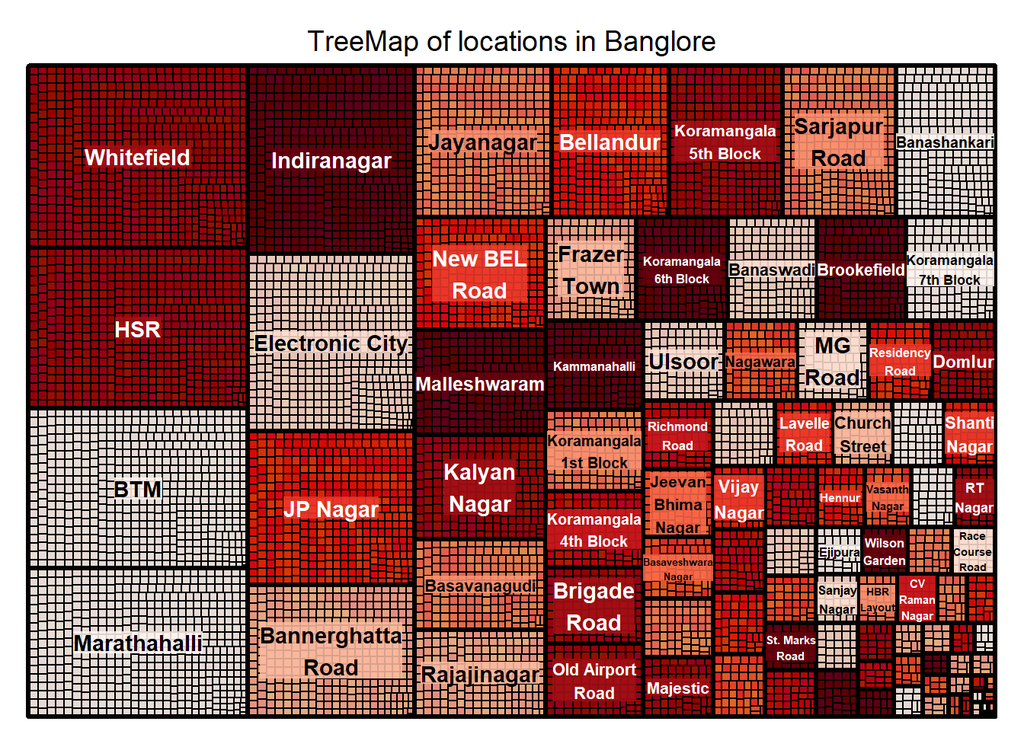

```r
treemap(ST3, #Your data frame object
        index=c("location", "name"),  #A list of your categorical variables
        vSize = "avg.rating",  #This is your quantitative variable
        type="index", #Type sets the organization and color scheme of your treemap
        palette = "Reds",  #Select your color palette from the RColorBrewer presets or make your own.
        title="TreeMap of locations in Banglore", #Customize your title
        fontsize.title = 14 #Change the font size of the title
        )
```

### Inference: This TreeMap shows the top locations in Banglore. BTM, Whitefield and HSR are the top location according to restaurant count.

## 5. Top Restaurants Outlets in Banglore

```r
names(data)
```

```
##  [1] "name"                        "online_order"
##  [3] "book_table"                  "rate"
##  [5] "votes"                       "location"
##  [7] "rest_type"                   "dish_liked"
##  [9] "cuisines"                    "approx_cost(for two people)"
## [11] "reviews_list"                "menu_item"
## [13] "listed_in(type)"             "listed_in(city)"
```

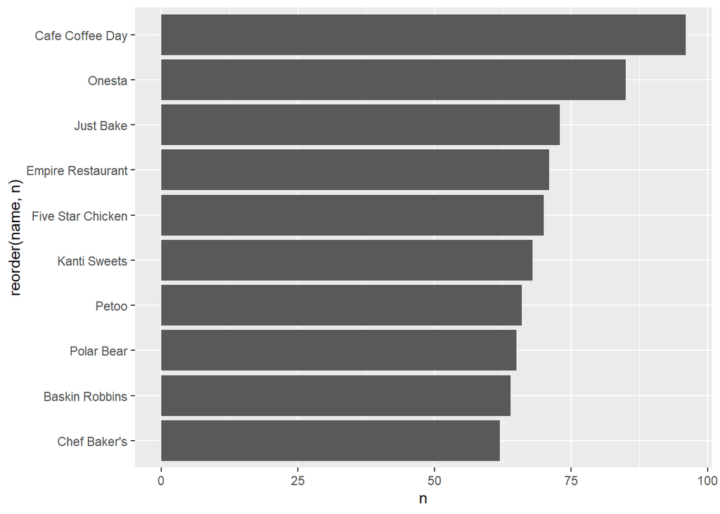

```r
top_rest_type <- data %>% select(name) %>% group_by(name) %>% count() %>% arrange(desc(n))
top_rest_type <- top_rest_type[1:10,]

top_rest_type %>%
  ggplot(aes(x=reorder(name,n),y=n))+
  geom_bar(stat = "identity") +
  coord_flip()
```

### Inference: As you can see Cafe coffee day,Onesta, Just Bake has the most number of outlets in and around bangalore.

## 6. How many of the restuarants do not accept online orders?

```r
DAOO <- data %>% select(name,online_order) %>% group_by(online_order) %>% count()
library(scales)
```

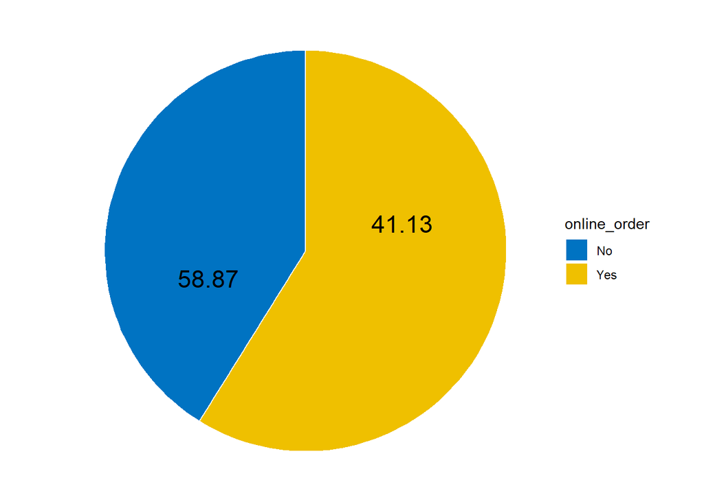

```r
mycols <- c("#0073C2FF", "#EFC000FF")
ggplot(DAOO, aes(x = "", y = n, fill = online_order)) +
  geom_bar(width = 1, stat = "identity", color = "white") +
  coord_polar("y", start = 0)+
  geom_text(aes(y = n/2 + c(0, cumsum(n)[-length(n)]),
                label = round(DAOO$n/sum(n)*100,2)), size=6)+
  scale_fill_manual(values = mycols) +
  theme_void()
```

### Inference: As clearly indicated,almost 60% of restaurants in Banglore accepts online orders. Nearly 40% of the restaurants do not accept online orders.

## 7. What is the ratio b/w restaurants that provide and do not provide table?

[figure not shown]

```r
ROTB <- data %>% select(book_table) %>% group_by(book_table) %>% count()

mycols <- c("#0073C2FF", "#EFC000FF")
ggplot(ROTB , aes(x = "", y = n, fill = book_table)) +
  geom_bar(width = 1, stat = "identity", color = "white") +
  coord_polar("y", start = 0)+
  geom_text(aes(y = n/13 + c(0, cumsum(n)[-length(n)]),
                label = round(DAOO$n/sum(n)*100,2)), size=4)+
  scale_fill_manual(values = mycols) +
  theme_void()
```

### Inference: Almost 90% of restaurants in Banglore do not provide table booking facility. In India you cannot find table booking facility in any average restaurants,usually only five star restaurants provides table booking.

## 8. Rating Distribution

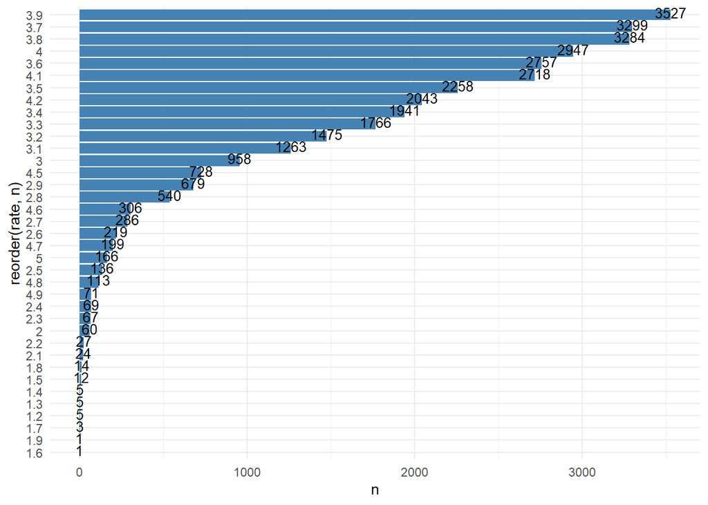

```r
RC <- data1 %>% select(rate)%>% group_by(rate) %>% count()
RC <- RC[-c(1,33,34),]
RC %>%
  ggplot(aes(x=reorder(rate,n),y=n))+
  geom_bar(stat = "identity", fill= "steelblue") + theme_minimal()+
  coord_flip() + geom_text(aes(label=n),vjust=0.3,size=3.5,color="black")
```

### Inference: We can see that 3.9 is the most common rating people have given to restaurants in Banglore, which means most of the restaurants are good.

## 9. Cost vs Rating

```r
data$rate <- gsub('\\s+', '', data$rate)
data$online_order <- gsub('\\s+', '', data$online_order)
data$`approx_cost(for two people)` <- gsub('\\s+', '', data$`approx_cost(for two people)`)

CR <- data %>% select(rate,online_order,`approx_cost(for two people)`) %>% arrange(desc(`approx_cost(for two people)`))
CR <- na.omit(CR)
names(CR)
```

```
## [1] "rate"                        "online_order"
## [3] "approx_cost(for two people)"
```

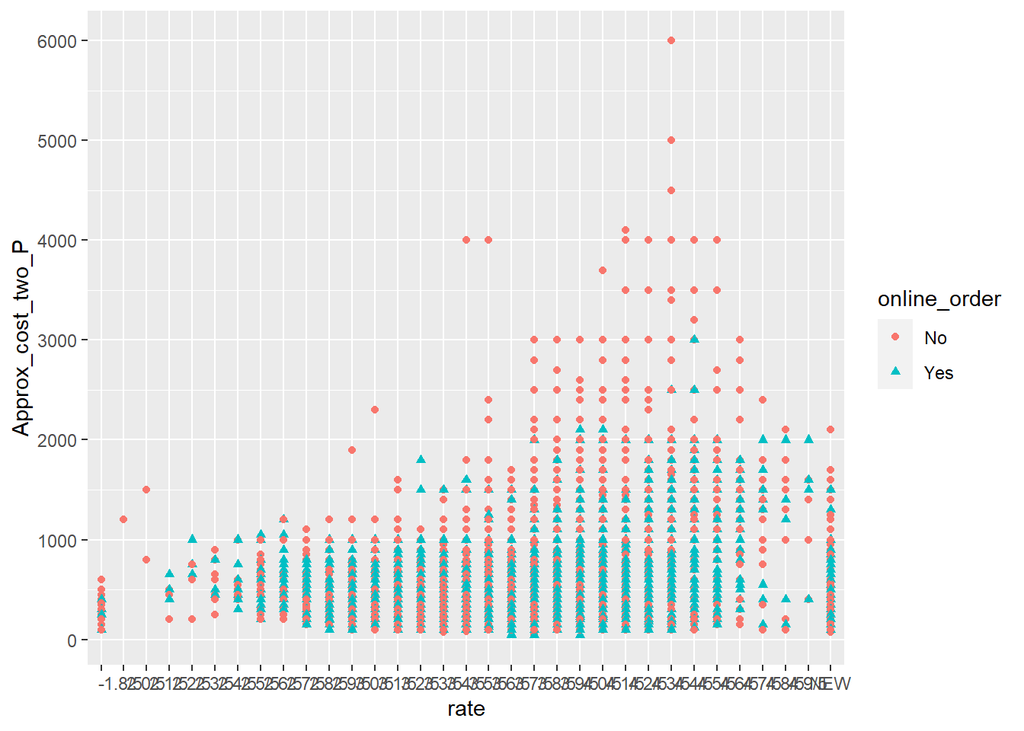

```r
names(CR)[3]<- "Approx_cost_two_P"
CR$Approx_cost_two_P <-as.numeric(CR$Approx_cost_two_P)
ggplot(CR, aes(x=rate, y=Approx_cost_two_P, color=online_order, shape=online_order)) +
  geom_point() +scale_y_continuous(breaks = seq(0,6000,1000))
```

## 10. Distribution of cost for two people

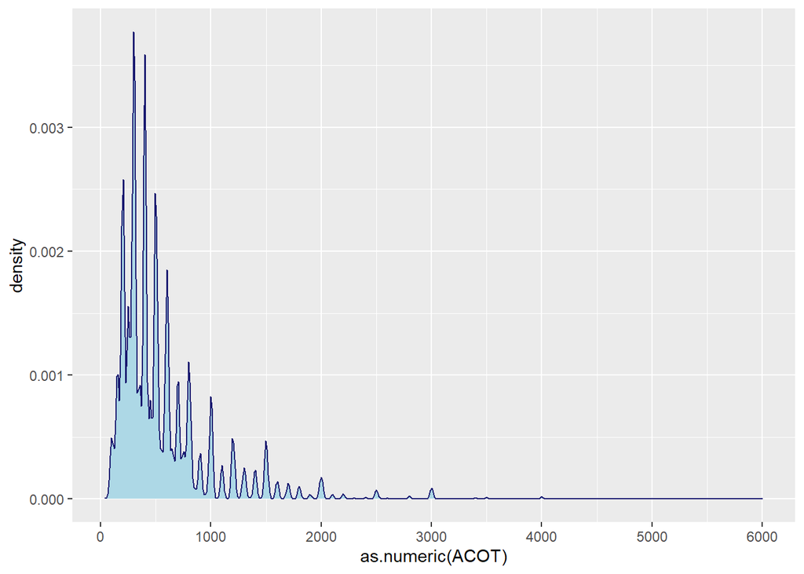

```r
ACOT <- data$`approx_cost(for two people)`
ggplot(data,aes(x=as.numeric(ACOT)))+ geom_density(adjust=1/2,color="midnightblue",fill="lightblue")+scale_x_continuous(breaks = seq(0,6000,1000))
```

## 11. Which are the most common restaurant type in Banglore?

```r
data$rest_type <- gsub('\\s+', '', data$rest_type)
MCR <- data %>% select(rest_type) %>% group_by(rest_type) %>% count() %>% arrange(desc(n)) %>% head(10)
MCR
```

```
## # A tibble: 10 x 2
## # Groups:   rest_type [10]
##    rest_type             n
##    <chr>             <int>
##  1 QuickBites        19132
##  2 CasualDining      10330
##  3 Cafe               3732
##  4 Delivery           2604
##  5 DessertParlor      2263
##  6 Takeaway,Delivery  2037
##  7 CasualDining,Bar   1154
##  8 Bakery             1141
##  9 BeverageShop        867
## 10 Bar                 697
```

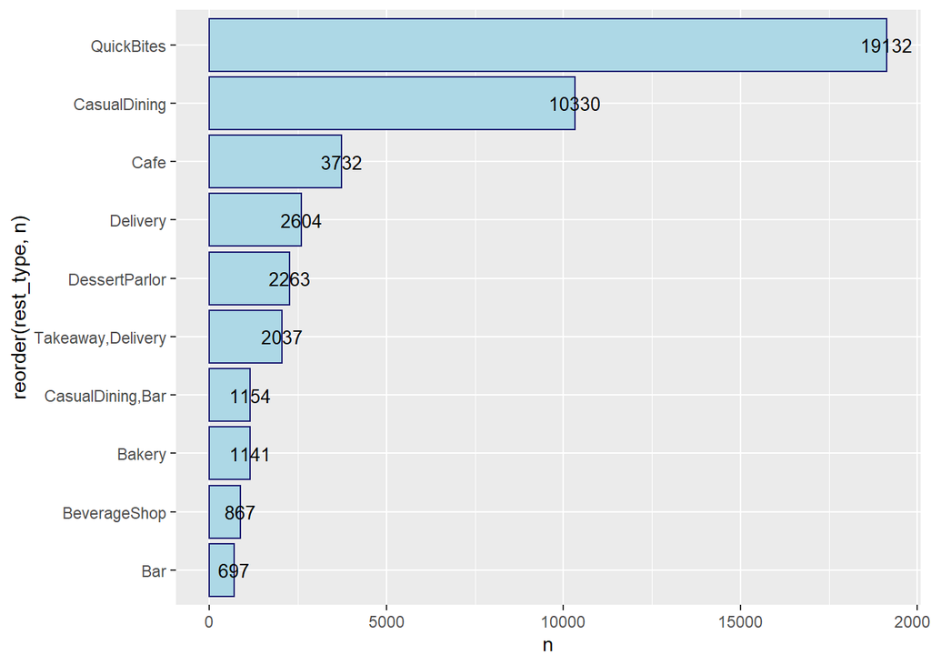

```r
MCR %>%
  ggplot(aes(x=reorder(rest_type,n),y=n))+
  geom_bar(stat = "identity",fill="lightblue",color="midnightblue") +
  coord_flip() +geom_text(aes(label=n),vjust=0.5,size=3.5,color="black")
```

### Inference: No doubt about this as Banglore is known as the tech capital of India,people having busy and modern life will prefer Quick Bites. We can observe tha Quick Bites type restaurants dominates.

## 12. BoxPlot for Average Cost for Two

```r
data$`approx_cost(for two people)` <- as.numeric(data$`approx_cost(for two people)`)
summary(data$`approx_cost(for two people)`,)
```

```
##    Min. 1st Qu.  Median    Mean 3rd Qu.    Max.    NA's
##    40.0   300.0   400.0   555.4   650.0  6000.0     346
```

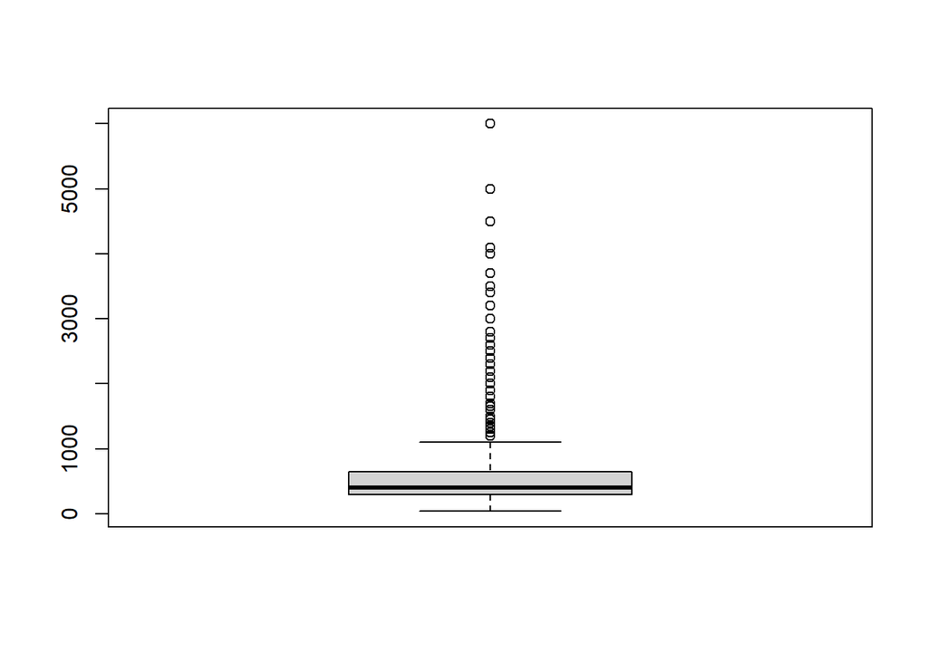

```r
boxplot(data$`approx_cost(for two people)`)
```

### Inference: The median approximate cost for two people is 400 for a single meal. 50 percent of restaurants charge between 300 and 650 for single meal for two people.

## 13. Which are the foodie areas?

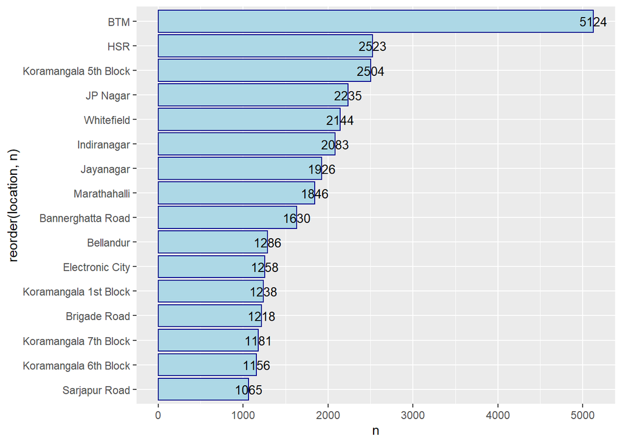

```r
FA <- data %>% select(location) %>% group_by(location) %>% count() %>% arrange(desc(n)) %>% head(16)

FA %>%
  ggplot(aes(x=reorder(location,n),y=n))+
  geom_bar(stat = "identity",fill="lightblue",color="darkblue") +
  coord_flip() +geom_text(aes(label=n),vjust=0.5,size=3.5,color="black")
```

### Inference: We can see that BTM,HSR and Koranmangala 5th block has the most number of restaurants. BTM dominates the section by having more than 5000 restaurants.

## 14. Which are the most common cuisines in each locations?

```r
CCEL <- data %>%
  select(location,cuisines) %>%
  group_by(location,cuisines)%>%
  count() %>%
  arrange(desc(n)) %>%
  head(15)
CCEL
```

```
## # A tibble: 15 x 3
## # Groups:   location, cuisines [15]
##    location              cuisines                  n
##    <chr>                 <chr>                 <int>
##  1 BTM                   North Indian, Chinese   379
##  2 BTM                   North Indian            340
##  3 Whitefield            North Indian            188
##  4 HSR                   North Indian            173
##  5 Bellandur             North Indian            161
##  6 JP Nagar              North Indian            157
##  7 Marathahalli          North Indian            155
##  8 Koramangala 1st Block North Indian            150
##  9 Marathahalli          North Indian, Chinese   145
## 10 Bannerghatta Road     North Indian, Chinese   130
## 11 HSR                   North Indian, Chinese   130
## 12 BTM                   Biryani                 120
## 13 BTM                   South Indian            113
## 14 BTM                   Fast Food               112
## 15 Whitefield            North Indian, Chinese   112
```

## 15. Wordcloud of dishes liked by cuisines and rest_type=QuickBites

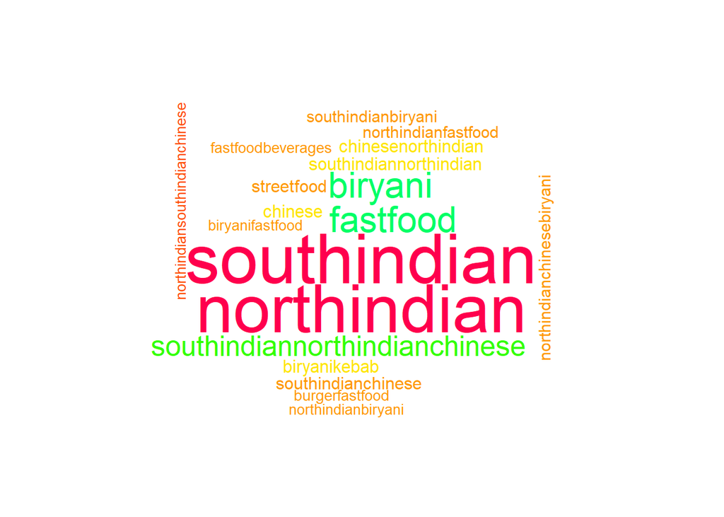

## 16. Average votes per restaurant by Country code

```r
d3 <- data2%>%
  group_by(Country)%>%
  summarise(
    count=n(),
    avg_votes=mean(Votes)
  )
d3
```

```
## # A tibble: 15 x 3
##    Country        count avg_votes
##    <chr>          <int>     <dbl>
##  1 Australia         24     111.
##  2 Brazil            60      19.6
##  3 Canada             4     103
##  4 India           8652     137.
##  5 Indonesia         21     772.
##  6 New Zealand       40     243.
##  7 Phillipines       22     407.
##  8 Qatar             20     164.
##  9 Singapore         20      31.9
## 10 South Africa      60     315.
## 11 Sri Lanka         20     146.
## 12 Turkey            34     431.
## 13 UAE               60     494.
## 14 United Kingdom    80     205.
## 15 United States    434     428.
```

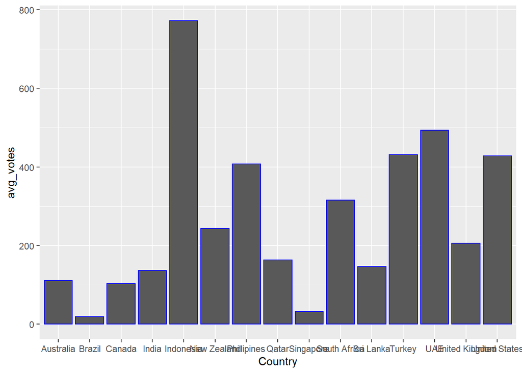

```r
ggplot(d3,aes(x=Country,y=avg_votes)) + geom_bar(stat="identity",color="Blue")
```

```r
d4 <- data2 %>%
  subset(Country == 'India')
table(d4$`Has Table booking`)
```

```
##
##    0    1
## 7541 1111
```

[figure not shown]

```r
pie(table(d4$`Has Online delivery`),c("Restaurants without\n table booking","Restaurants with \nTable Booking"),main="Pie graph to represnt distribution\n of restaurants offering / not offering online Table Booking")
```

## Inference: Out of 8652 restaurants only 1111 restaurants offer table booking, rest of them dont have the option of table booking thus highlights the trend that more restaurants opt for online delivery rather than opening physical restaurants especially in metropolitan cities of India